# Protein Differential Abundance Analysis

2024-06-11

Differential Abundance Analysis of TMT-MS data

The overall design is a genetically targeted proximity labeling experiment with dCas9 as the targeting moiety. The goal is to explore this dataset, to initially identify any proteins that are showing differences in abundance across the various conditions. Then lastly, to perform differential abundance analysis between different conditions.

There are 5 conditions (p1, p2, p3, NoGp, NoGn) each with 3 biological replicates.There are 15 columns representing the different conditions and their replicates. Each column represents a TMT channel. The values listed are abundances or intensities.

Targeted positive controls:

- The three positive conditions are p1, p2, and p3, with 3 replicates each.
- Each “p” group represents separate single guide sgRNAs, targeting the promoter of FOXP2 just upstream of the transcription start site.

Untargeted negative controls:

- NoG is the dCas9 on its own with no guide RNA as a negative control.
- NoGp is a negative control that includes full labeling conditions.
- NoGn excluded the biotin phenol needed to actually do the labeling and represents background endogenously biotinylated proteins.

First, a normal distribution of data is assumed, and log intensities are compared across conditions, with z scores determined for proteins showing log2 > 1 fold change. Then the data is modeled to a normal distribution and a t-test statistic is calculated with FDR-adjusted p-value to determine the significance of the observed fold changes.

As in a regular R script in RStudio, a single line of code can be run with Command-Enter (Mac OS) or Ctrl-Enter (Windows). Whole chunks of code can be run with Command(/Ctrl) + Shift + Enter **or** by clicking the green “>” button in the top-right corner of the chunk. Alternatively, these options can also be implemented by selecting lines of code and choosing the desired option from the drop-down menu in the “Run” tab, in the top-right corner of the of Source section of RStudio.

To comment or uncomment a series of lines, highlight the lines and use Command(/Ctrl) + Shift + C.

R packages `preprocessCore`, `ggplot2`, `dplyr`, `reshape`, `multcomp` and `nlme` and `Enhanced Volcano` are required for this workflow. They can be installed using the following commands:

```r
# install.packages("preprocessCore")
# install.packages("ggplot2")
# install.packages("dplyr")
# install.packages("multcomp")
# install.packages("nlme")
# install.packages("reshape2")
# install.packages("EnchancedVolcano")

# If install.packages("packagename") command fails in newer versions of R uncomment and run the commands:
# if (!require("BiocManager", quietly = TRUE))
#    install.packages("BiocManager")
# BiocManager::install("packagename")
```

Once installed, load the packages.

```r
# Load required libraries
library(preprocessCore) # For data preprocessing
library(reshape2)       # For data preprocessing
library(ggplot2)        # For data visualization
library(dplyr)          # For data manipulation
library(nlme)           # For differential analysis
library(multcomp)       # For multiple comparisons of k groups in general linear models
# Load the dataset
data <- read.csv("~/Desktop/Comp_MS/proteomicsData.csv")

head(data)
```

```
##   ProteinID  p1_1  p1_2  p1_3   p2_1  p2_2  p2_3  p3_1  p3_2  p3_3 NoGp_1
## 1    P23763  13.2  10.3   9.6   14.0   9.7   7.7  11.2  14.8  13.0    9.1
## 2    Q9UI95  31.0  25.4  15.4   38.2  12.5  24.0  30.4  23.6  18.2   26.9
## 3    Q13423 743.4 520.9 404.2 1187.3 329.2 619.6 627.2 714.5 576.0  551.9
## 4    Q6F5E8 128.6 126.2 153.5  140.5 130.2 114.2 122.8 152.4 162.5  121.1
## 5    Q00577 189.0  79.7 247.1   95.3 152.1 154.1 156.9  72.8 132.5  172.6
## 6    Q9C0J8 156.4 175.3 128.7  231.4 133.4 157.6 141.6 200.3 170.3  169.4
##   NoGp_2 NoGp_3 NoGn_1 NoGn_2 NoGn_3  Pool
## 1   14.5   11.1    9.1   11.1   12.0   7.7
## 2   11.0   30.4   20.2   11.5   13.5  20.0
## 3  511.8  614.9  743.4  398.0  530.5 554.2
## 4  107.7  117.9   76.9  132.0  104.9 135.3
## 5   61.9  257.7   79.5   56.1   38.6 138.0
## 6  150.2  115.1  102.4  125.4  121.7 134.5
```

```r
# Display the structure of the dataset
str(data)
```

```
## 'data.frame':    5074 obs. of  17 variables:
##  $ ProteinID: chr  "P23763" "Q9UI95" "Q13423" "Q6F5E8" ...
##  $ p1_1     : num  13.2 31 743.4 128.6 189 ...
##  $ p1_2     : num  10.3 25.4 520.9 126.2 79.7 ...
##  $ p1_3     : num  9.6 15.4 404.2 153.5 247.1 ...
##  $ p2_1     : num  14 38.2 1187.3 140.5 95.3 ...
##  $ p2_2     : num  9.7 12.5 329.2 130.2 152.1 ...
##  $ p2_3     : num  7.7 24 619.6 114.2 154.1 ...
##  $ p3_1     : num  11.2 30.4 627.2 122.8 156.9 ...
##  $ p3_2     : num  14.8 23.6 714.5 152.4 72.8 ...
##  $ p3_3     : num  13 18.2 576 162.5 132.5 ...
##  $ NoGp_1   : num  9.1 26.9 551.9 121.1 172.6 ...
##  $ NoGp_2   : num  14.5 11 511.8 107.7 61.9 ...
##  $ NoGp_3   : num  11.1 30.4 614.9 117.9 257.7 ...
##  $ NoGn_1   : num  9.1 20.2 743.4 76.9 79.5 ...
##  $ NoGn_2   : num  11.1 11.5 398 132 56.1 ...
##  $ NoGn_3   : num  12 13.5 530.5 104.9 38.6 ...
##  $ Pool     : num  7.7 20 554.2 135.3 138 ...
```

```r
# Load necessary libraries
library(preprocessCore)
library(reshape2)

# Step 1: Exclude the ProteinID column for transformation and normalization
# and the Pool column for initial processing
intensity_data <- data[, -1]
pool_column <- intensity_data$Pool
intensity_data <- intensity_data[, -ncol(intensity_data)]

# Step 2: Normalize each intensity value by the corresponding value in the "Pool" column
normalized_data <- sweep(intensity_data, 1, pool_column, FUN = "/")

# Step 3: Apply log2 transformation
normalized_data <- log2(normalized_data + 1)  # Adding 1 to avoid log2(0)

# Step 4: Add back the ProteinID column
normalized_data <- cbind(ProteinID = data$ProteinID, normalized_data)
colnames(normalized_data) <- colnames(data)[-ncol(data)]  # Ensure column names are consistent

# Display the first few rows of the normalized data
head(normalized_data)
```

```
##   ProteinID      p1_1      p1_2      p1_3     p2_1      p2_2     p2_3      p3_1
## 1    P23763 1.4405726 1.2250666 1.1678417 1.494765 1.1761570 1.000000 1.2954559
## 2    Q9UI95 1.3504972 1.1826923 0.8237494 1.541019 0.7004397 1.137504 1.3334237
## 3    Q13423 1.2273671 0.9559922 0.7902212 1.651852 0.6726601 1.082708 1.0920189
## 4    Q6F5E8 0.9638295 0.9506491 1.0939089 1.027461 0.9725500 0.882878 0.9317683
## 5    Q00577 1.2446224 0.6576731 1.4805649 0.757518 1.0718820 1.081794 1.0955576
## 6    Q9C0J8 1.1129171 1.2037310 0.9685533 1.443843 0.9940884 1.118856 1.0375847
##        p3_2      p3_3    NoGp_1    NoGp_2    NoGp_3    NoGn_1    NoGn_2
## 1 1.5469947 1.4267004 1.1255309 1.5276293 1.2878023 1.1255309 1.2878023
## 2 1.1243281 0.9335726 1.2295879 0.6322682 1.3334237 1.0071955 0.6553518
## 3 1.1948724 1.0280995 0.9970032 0.9437288 1.0769197 1.2273671 0.7808579
## 4 1.0884034 1.1381819 0.9222344 0.8447945 0.9041156 0.6492628 0.9822980
## 5 0.6112066 0.9709603 1.1703896 0.5346102 1.5197388 0.6563471 0.4921319
## 6 1.3156934 1.1802567 1.1759905 1.0818363 0.8920118 0.8166720 0.9503505
##      NoGn_3
## 1 1.3552653
## 2 0.7441611
## 3 0.9688175
## 4 0.8280743
## 5 0.3558171
## 6 0.9296643
```

```r
# Calculate average log2 intensities for conditions
average_log_intensity_control <- rowMeans(normalized_data[, grep("^p[1-3]_", names(normalized_data))], na.rm = TRUE)
average_log_intensity_NoGp <- rowMeans(normalized_data[, grep("^NoGp", names(normalized_data))], na.rm = TRUE)
average_log_intensity_NoGn <- rowMeans(normalized_data[, grep("^NoGn", names(normalized_data))], na.rm = TRUE)

# Calculate log2 fold changes
log2_fold_change_NoGp <- average_log_intensity_NoGp - average_log_intensity_control
log2_fold_change_NoGn <- average_log_intensity_NoGn - average_log_intensity_control

# Calculate Z-scores for each fold change
z_score_NoGp <- (log2_fold_change_NoGp - mean(log2_fold_change_NoGp, na.rm = TRUE)) / sd(log2_fold_change_NoGp, na.rm = TRUE)
z_score_NoGn <- (log2_fold_change_NoGn - mean(log2_fold_change_NoGn, na.rm = TRUE)) / sd(log2_fold_change_NoGn, na.rm = TRUE)

# Create data frame for results
fold_change_data <- data.frame(
  ProteinID = normalized_data$ProteinID,
  log2_fold_change_NoGp = log2_fold_change_NoGp,
  log2_fold_change_NoGn = log2_fold_change_NoGn,
  z_score_NoGp = z_score_NoGp,
  z_score_NoGn = z_score_NoGn
)

# Filter significant proteins with log2 fold change > 1
significant_proteins_NoGp <- fold_change_data[abs(fold_change_data$log2_fold_change_NoGp) > 1, ]
significant_proteins_NoGn <- fold_change_data[abs(fold_change_data$log2_fold_change_NoGn) > 1, ]

# Save the results to a CSV file
# write.csv(fold_change_data, 'differential_analysis_foldchange_zscores.csv', row.names = FALSE)
# write.csv(significant_proteins_NoGp, 'significant_proteins_NoGp_zscores.csv', row.names = FALSE)
# write.csv(significant_proteins_NoGn, 'significant_proteins_NoGn_zscores.csv', row.names = FALSE)

# Print significant proteins
head(significant_proteins_NoGp)
```

```
##      ProteinID log2_fold_change_NoGp log2_fold_change_NoGn z_score_NoGp
## NA        <NA>                    NA                    NA           NA
## NA.1      <NA>                    NA                    NA           NA
## NA.2      <NA>                    NA                    NA           NA
## NA.3      <NA>                    NA                    NA           NA
## NA.4      <NA>                    NA                    NA           NA
## NA.5      <NA>                    NA                    NA           NA
##      z_score_NoGn
## NA             NA
## NA.1           NA
## NA.2           NA
## NA.3           NA
## NA.4           NA
## NA.5           NA
```

```r
head(significant_proteins_NoGn)
```

```
##     ProteinID log2_fold_change_NoGp log2_fold_change_NoGn z_score_NoGp
## NA       <NA>                    NA                    NA           NA
## 29     Q5M9N0            0.06164829              1.102898    0.6132964
## 45     Q13228            0.12263726              1.202330    1.0916508
## 101    O75635            0.19548122              1.094100    1.6629875
## 117    Q9NSC2           -0.38726038              1.002130   -2.9076263
## 267    P48594            0.39666113              1.671807    3.2409006
##     z_score_NoGn
## NA            NA
## 29      3.184158
## 45      3.429007
## 101     3.162491
## 117     2.936016
## 267     4.585091
```

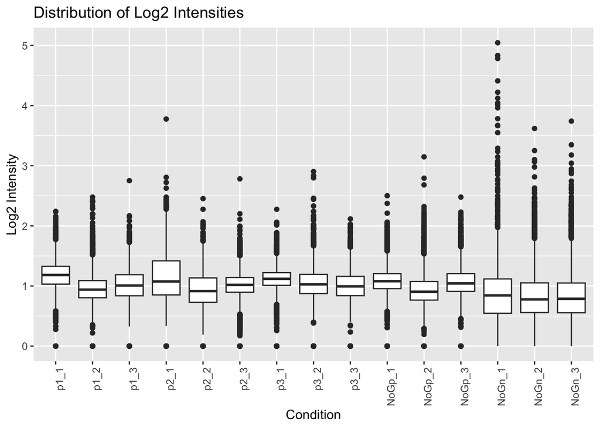

```r
# Melt the data for visualization
melted_data <- melt(normalized_data, id.vars = "ProteinID")

# Plot the distribution of log2 intensities
ggplot(melted_data, aes(x = variable, y = value)) +
  geom_boxplot() +
  theme(axis.text.x = element_text(angle = 90, hjust = 1)) +
  labs(title = "Distribution of Log2 Intensities", x = "Condition", y = "Log2 Intensity")
```

```r
library(dplyr)
library(tidyr)
# Reshape the data into a longer format
long_data <- normalized_data %>%
  pivot_longer(cols = -ProteinID, names_to = "Condition") %>%
  separate(Condition, into = c("Condition", "Replicate"), sep = "_")

# Remove the numerical suffixes from the column names
long_data$Condition <- gsub("\\_\\d+", "", long_data$Condition)

# Calculate the average for each condition
averaged_data <- long_data %>%
  group_by(ProteinID, Condition) %>%
  summarise(Average = mean(value))
# Reshape the data back to its original wide format
averaged_data <- pivot_wider(averaged_data, names_from = Condition, values_from = Average)

# View the first few rows of the averaged data
head(averaged_data)
```

```
## # A tibble: 6 × 6
## # Groups:   ProteinID [6]
##   ProteinID   NoGn  NoGp    p1    p2    p3
##   <chr>      <dbl> <dbl> <dbl> <dbl> <dbl>
## 1 A0A075B767 0.705 0.875 0.936 1.14  1.00
## 2 A0A087WUL8 0.193 0.981 1.11  0.988 1.05
## 3 A0A096LP55 0.273 0.824 0.941 0.917 0.967
## 4 A0A0B4J2A2 0.705 0.875 0.936 1.14  1.00
## 5 A0A0B4J2D5 1.01  1.08  0.977 1.15  1.14
## 6 A0A0U1RRL7 0.395 0.966 1.10  1.07  1.15
```

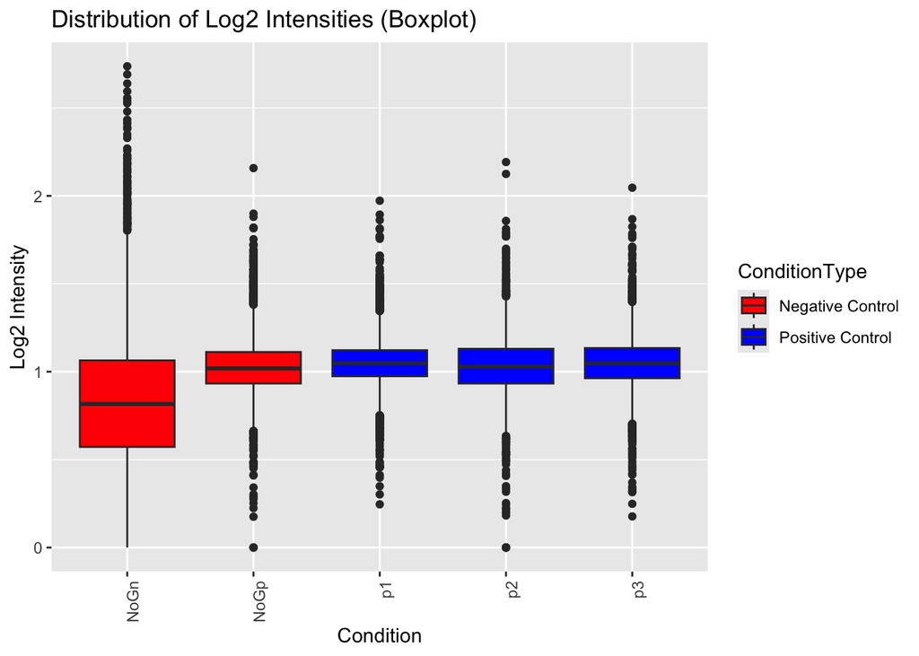

```r
# Melt the data for visualization
melted_data <- melt(averaged_data, id.vars = "ProteinID")

# Add a column for the condition type (control or negative control)
melted_data$ConditionType <- ifelse(melted_data$variable %in% c("p1", "p2", "p3"), "Positive Control", "Negative Control")

# Plot the distribution of log2 intensities using boxplot
ggplot(melted_data, aes(x = variable, y = value, fill = ConditionType)) +
  geom_boxplot() +
  scale_fill_manual(values = c("Positive Control" = "blue", "Negative Control" = "red")) +
  theme(axis.text.x = element_text(angle = 90, hjust = 1)) +
  labs(title = "Distribution of Log2 Intensities (Boxplot)", x = "Condition", y = "Log2 Intensity")
```

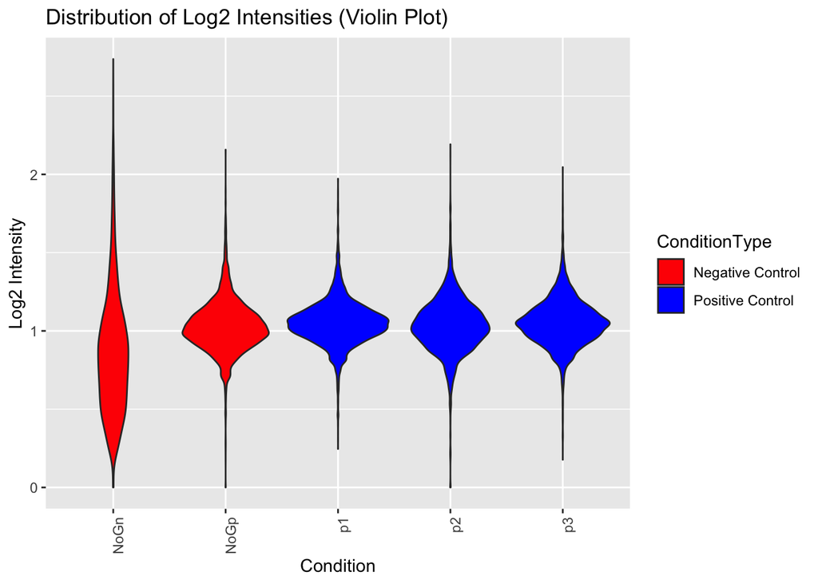

```r
# Plot the distribution of log2 intensities using violin plot
ggplot(melted_data, aes(x = variable, y = value, fill = ConditionType)) +
  geom_violin() +
  scale_fill_manual(values = c("Positive Control" = "blue", "Negative Control" = "red")) +
  theme(axis.text.x = element_text(angle = 90, hjust = 1)) +
  labs(title = "Distribution of Log2 Intensities (Violin Plot)", x = "Condition", y = "Log2 Intensity")
```